# Dataviz Notebook #2

Dans ce notebook, nous allons préparer la donnée, afin d’obtenir la donnée transformée escomptée, à savoir un flux d’artificialisation par commune et par année.

## Lecture des données

Lisons les données de flux

```r
library(tidyverse)

flux <- read_csv("../data/obs_artif_conso_com_2009_2020_V2.csv")
```

## Sélection des colonnes

Nous nous intéressons aux flux entre années et allons sélectionner seulement les colonnes utiles, à savoir, les colonnes `art09mix10`, `art10mix11`, etc…

```r
myCols <-  names(flux)[grep("^art[0-9]{2}\\S+[0-9]{2}$", names(flux))]
myCols
```

```
##  [1] "art09act10" "art09hab10" "art09mix10" "art09inc10" "art10act11"
##  [6] "art10hab11" "art10mix11" "art10inc11" "art11act12" "art11hab12"
## [11] "art11mix12" "art11inc12" "art12act13" "art12hab13" "art12mix13"
## [16] "art12inc13" "art13act14" "art13hab14" "art13mix14" "art13inc14"
## [21] "art14act15" "art14hab15" "art14mix15" "art14inc15" "art15act16"
## [26] "art15hab16" "art15mix16" "art15inc16" "art16act17" "art16hab17"
## [31] "art16mix17" "art16inc17" "art17act18" "art17hab18" "art17mix18"
## [36] "art17inc18" "art18act19" "art18hab19" "art18mix19" "art18inc19"
## [41] "art19act20" "art19hab20" "art19mix20" "art19inc20"
```

## Transformation du format wide vers long

Nous utiliserons **ggplot2** pour représenter les données. Nous aurons besoin, avant d’utiliser les données, de passer d’un format wide (en largeur) à un format long (en longueur).

En effet, les noms de colonnes, comme `art19hab20` ou `art13mix14` portent en eux des attributs : type de flux, et année du flux, que nous aimerions bien voir apparaître dans les cellules de notre tableau.

Par exemple, pour `art19hab20`, l’année du flux est l’année 2019 et concerne les flux vers l’habitat. On pourrait imaginer avoir une colonne pour l’année du flux, et une colonne pour son type.

Pour `art13mix14`, le flux est concerne les flux d’artificialisation vers le mixte pour l’année 2013.

Voici la différence entre un fichier de type *wide* et un fichier de type *long* :

### Wide

| id | nom | sport | ville |
| --- | --- | --- | --- |
| 1 | mathieu | squash | Aix-en-Provence |

### Long

| id | variable | valeur |
| --- | --- | --- |
| 1 | nom | mathieu |
| 1 | sport | squash |
| 1 | ville | Aix-en-Provence |

à cette structure

| idcom | year | type | value |
| --- | --- | --- | --- |
| 13001 | 2019 | habitat | 111096 |

### Transformation au format *long* avec `gather`

Prenons l’exemple d’Aix en Provence. Les données sont dans un format wide (le plus commun, avec les variables en colonnes) :

```r
df <- flux %>% filter(idcom == "13001")
df[, c("idcom", "idcomtxt", myCols)]
```

| idcom | idcomtxt | art09act10 | art09hab10 | art09mix10 | art09inc10 | art10act11 | art10hab11 | art10mix11 | art10inc11 | art11act12 | art11hab12 | art11mix12 | art11inc12 | art12act13 | art12hab13 | art12mix13 | art12inc13 | art13act14 | art13hab14 | art13mix14 | art13inc14 | art14act15 | art14hab15 | art14mix15 | art14inc15 | art15act16 | art15hab16 | art15mix16 | art15inc16 | … |
| --- | --- | --- | --- | --- | --- | --- | --- | --- | --- | --- | --- | --- | --- | --- | --- | --- | --- | --- | --- | --- | --- | --- | --- | --- | --- | --- | --- | --- | --- | --- |
| 13001 | Aix-en-Provence | 70439 | 223015 | 21156 | 2502 | 70440 | 223016 | 21157 | 2499 | 83789 | 343830 | 25686 | 3120 | 74212 | 268500 | 12746 | 1 | 63133 | 308764 | 22835 | 0 | 296945 | 301509 | 14640 | 3 | 67304 | 209214 | 20621 | 9649 | … |

Pour transformer au format long, nous utilisons la fonction `gather` :

```r
df <- df[, c("idcom", "idcomtxt", myCols)]
df <- gather(df,
             "variable", # key
             "value",    # value
             myCols) # variables
```

```
## Note: Using an external vector in selections is ambiguous.
## i Use `all_of(myCols)` instead of `myCols` to silence this message.
## i See <https://tidyselect.r-lib.org/reference/faq-external-vector.html>.
```

```r
df
```

| idcom | idcomtxt | variable | value |
| --- | --- | --- | --- |
| 13001 | Aix-en-Provence | art09act10 | 70439 |
| 13001 | Aix-en-Provence | art09hab10 | 223015 |
| 13001 | Aix-en-Provence | art09mix10 | 21156 |
| 13001 | Aix-en-Provence | art09inc10 | 2502 |
| 13001 | Aix-en-Provence | art10act11 | 70440 |
| 13001 | Aix-en-Provence | art10hab11 | 223016 |
| 13001 | Aix-en-Provence | art10mix11 | 21157 |
| 13001 | Aix-en-Provence | art10inc11 | 2499 |
| 13001 | Aix-en-Provence | art11act12 | 83789 |
| 13001 | Aix-en-Provence | art11hab12 | 343830 |

[output cut: 34 more lines]

La colonne `variable` comporte des valeurs telles que `art09hab10` pour le flux d’artificialisation vers l’habitat de 2009 à 2010 :

```r
unique(df$variable)
```

```
##  [1] "art09act10" "art09hab10" "art09mix10" "art09inc10" "art10act11"
##  [6] "art10hab11" "art10mix11" "art10inc11" "art11act12" "art11hab12"
## [11] "art11mix12" "art11inc12" "art12act13" "art12hab13" "art12mix13"
## [16] "art12inc13" "art13act14" "art13hab14" "art13mix14" "art13inc14"
## [21] "art14act15" "art14hab15" "art14mix15" "art14inc15" "art15act16"
## [26] "art15hab16" "art15mix16" "art15inc16" "art16act17" "art16hab17"
## [31] "art16mix17" "art16inc17" "art17act18" "art17hab18" "art17mix18"
## [36] "art17inc18" "art18act19" "art18hab19" "art18mix19" "art18inc19"
## [41] "art19act20" "art19hab20" "art19mix20" "art19inc20"
```

## Année et destination du flux

Nous allons extraire l’année et le type (habitat, activité, mixte, inconnu) depuis le champ `variable` :

```r
df$year <- gsub("art([0-9]{2})(\\S+)[0-9]{2}", "20\\1", df$variable)
df$type <- gsub("art([0-9]{2})(\\S+)[0-9]{2}", "\\2", df$variable)
```

Voici le résultat:

```r
df %>% head
```

| idcom | idcomtxt | variable | value | year | type |
| --- | --- | --- | --- | --- | --- |
| 13001 | Aix-en-Provence | art09act10 | 70439 | 2009 | act |
| 13001 | Aix-en-Provence | art09hab10 | 223015 | 2009 | hab |
| 13001 | Aix-en-Provence | art09mix10 | 21156 | 2009 | mix |
| 13001 | Aix-en-Provence | art09inc10 | 2502 | 2009 | inc |
| 13001 | Aix-en-Provence | art10act11 | 70440 | 2010 | act |
| 13001 | Aix-en-Provence | art10hab11 | 223016 | 2010 | hab |

## Retraitement

Améliorons le champ `type` pour avoir des libellés plus parlants :

```r
df <- df %>% mutate(type = case_when(
  type == "hab" ~ "Habitat",
  type == "act" ~ "Activité",
  type == "mix" ~ "Mixte",
  type == "inc" ~ "Inconnu",
))
```

Au final, nous n’avons plus besoin de la variable variable :

```r
df$variable <- NULL
```

Voici notre fichier df au final :

```r
df
```

| idcom | idcomtxt | value | year | type |
| --- | --- | --- | --- | --- |
| 13001 | Aix-en-Provence | 70439 | 2009 | Activité |
| 13001 | Aix-en-Provence | 223015 | 2009 | Habitat |
| 13001 | Aix-en-Provence | 21156 | 2009 | Mixte |
| 13001 | Aix-en-Provence | 2502 | 2009 | Inconnu |
| 13001 | Aix-en-Provence | 70440 | 2010 | Activité |
| 13001 | Aix-en-Provence | 223016 | 2010 | Habitat |
| 13001 | Aix-en-Provence | 21157 | 2010 | Mixte |
| 13001 | Aix-en-Provence | 2499 | 2010 | Inconnu |
| 13001 | Aix-en-Provence | 83789 | 2011 | Activité |
| 13001 | Aix-en-Provence | 343830 | 2011 | Habitat |

[output cut: 34 more lines]

## Fonction `getStatsFlux`

Créons une fonction qui retourne les flux pour une commune donnée à partir de son code INSEE :

```r
getStatsFlux <- function(flux, codeInsee) {

  # Filtre par commune
  df <- flux %>% filter(idcom == codeInsee)

  # Colonnes intéressantes
  myCols <-  names(flux)[grep("^art[0-9]{2}\\S+[0-9]{2}$", names(flux))]
  df <- df[, c("idcom", "idcomtxt", myCols)]

  # Long format
  df <- df %>% gather("variable", # key
                      "value",    # value
                      myCols) # variables

  # Année et type
  df$year <- gsub("art([0-9]{2})(\\S+)[0-9]{2}", "20\\1", df$variable)
  df$type <- gsub("art([0-9]{2})(\\S+)[0-9]{2}", "\\2", df$variable)

  # Renomme les valeurs de type
  df <- df %>% mutate(type = case_when(
  type == "hab" ~ "Habitat",
  type == "act" ~ "Activité",
  type == "mix" ~ "Mixte",
  type == "inc" ~ "Inconnu"))

  # Réagence les colonnes
  df <- df[, c("idcom", "idcomtxt", "year", "type", "value")]

  return(df)
}

flux %>% getStatsFlux("13001")
```

| idcom | idcomtxt | year | type | value |
| --- | --- | --- | --- | --- |
| 13001 | Aix-en-Provence | 2009 | Activité | 70439 |
| 13001 | Aix-en-Provence | 2009 | Habitat | 223015 |
| 13001 | Aix-en-Provence | 2009 | Mixte | 21156 |
| 13001 | Aix-en-Provence | 2009 | Inconnu | 2502 |
| 13001 | Aix-en-Provence | 2010 | Activité | 70440 |
| 13001 | Aix-en-Provence | 2010 | Habitat | 223016 |
| 13001 | Aix-en-Provence | 2010 | Mixte | 21157 |
| 13001 | Aix-en-Provence | 2010 | Inconnu | 2499 |
| 13001 | Aix-en-Provence | 2011 | Activité | 83789 |
| 13001 | Aix-en-Provence | 2011 | Habitat | 343830 |

[output cut: 34 more lines]

Enregistrons cette fonction dans le fichier `helpers.R`

## Data Engineering

Pas mal d’étapes de préparation sont parfois nécessaires avant de créer des applications de dataviz.

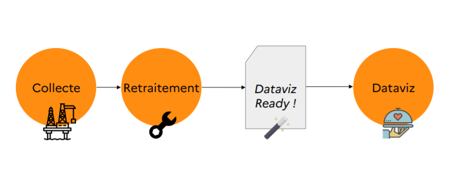

Voici la chaîne de données, assez conséquente, pour Cartofriches :

[figure not shown]